# GLM_exercise_2

Clarke van Steenderen

2024-04-22

# Practice exercise 2

```r
if (!require("pacman"))
  install.packages("pacman")
```

```r
pacman::p_load(xlsx, janitor, ggplot2, Rmisc, dplyr,
               tidyverse, visreg, glmmTMB, gtsummary, effects, ggeffects,
               patchwork, emmeans, GLMsData)

# Set plot theme
theme_set(theme_classic() +
theme(panel.border = element_rect(colour = "black", fill = NA),
axis.text = element_text(colour = "black"),
axis.title.x = element_text(margin = unit(c(2, 0, 0, 0), "mm")),
axis.title.y = element_text(margin = unit(c(0, 4, 0, 0), "mm")),
legend.position = "none"))
```

Read in the data collected in the 1970s on the smoking habits of 654 youths. Female = 0, male = 1, non-smoker = 0, smoker = 1, FEV = Forced Expiratory Volume (lung capacity). It seems weird that smokers appear to have a higher lung capacity than non-smokers! Split the plots so that they account for age and height:

```r
library(GLMsData)
data(lungcap)

str(lungcap)
```

```
## 'data.frame':    654 obs. of  5 variables:
##  $ Age   : int  3 4 4 4 4 4 4 5 5 5 ...
##  $ FEV   : num  1.072 0.839 1.102 1.389 1.577 ...
##  $ Ht    : num  46 48 48 48 49 49 50 46.5 49 49 ...
##  $ Gender: Factor w/ 2 levels "F","M": 1 1 1 1 1 1 1 1 1 1 ...
##  $ Smoke : int  0 0 0 0 0 0 0 0 0 0 ...
```

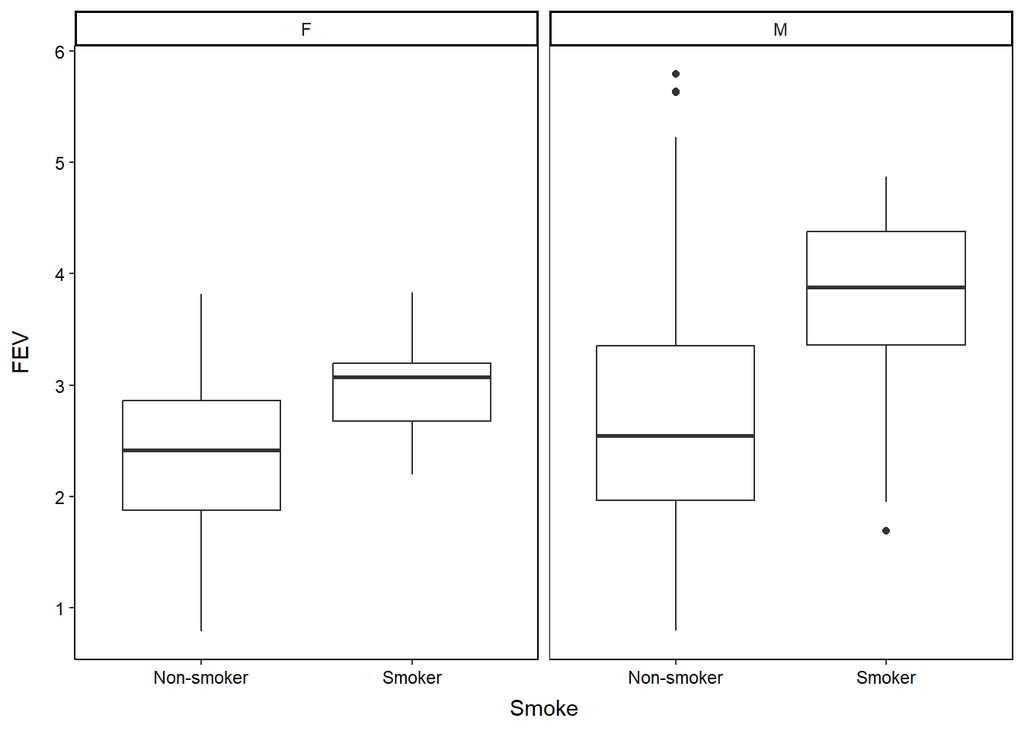

```r
lungcap$Smoke = as.factor(lungcap$Smoke)

# Plot FEV for smokers and non-smokers
ggplot2::ggplot(data = lungcap, aes(x = Smoke, y = FEV)) +
  geom_boxplot() +
  facet_wrap(~Gender) +
  scale_x_discrete(labels = c("0" = "Non-smoker",
                               "1" = "Smoker"))
```

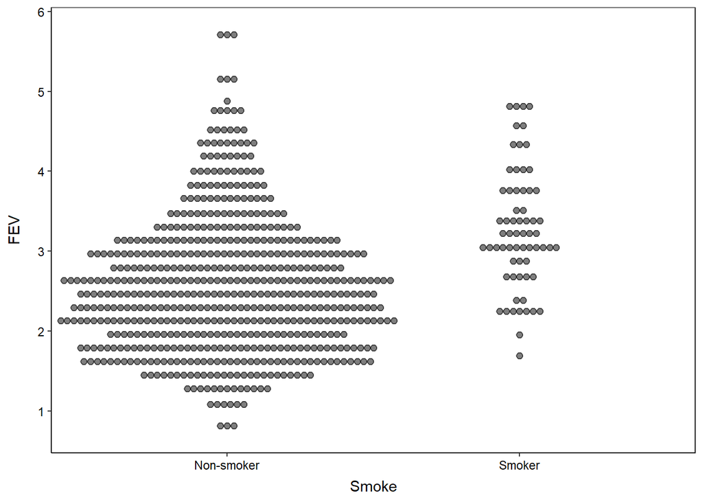

```r
# Plot FEV for smokers and non-smokers
ggplot2::ggplot(data = lungcap, aes(x = Smoke, y = FEV)) +
  geom_dotplot(binaxis = "y", stackdir = "center", dotsize = 0.5, alpha = 0.5) +
  scale_x_discrete(labels = c("0" = "Non-smoker",
                               "1" = "Smoker"))
```

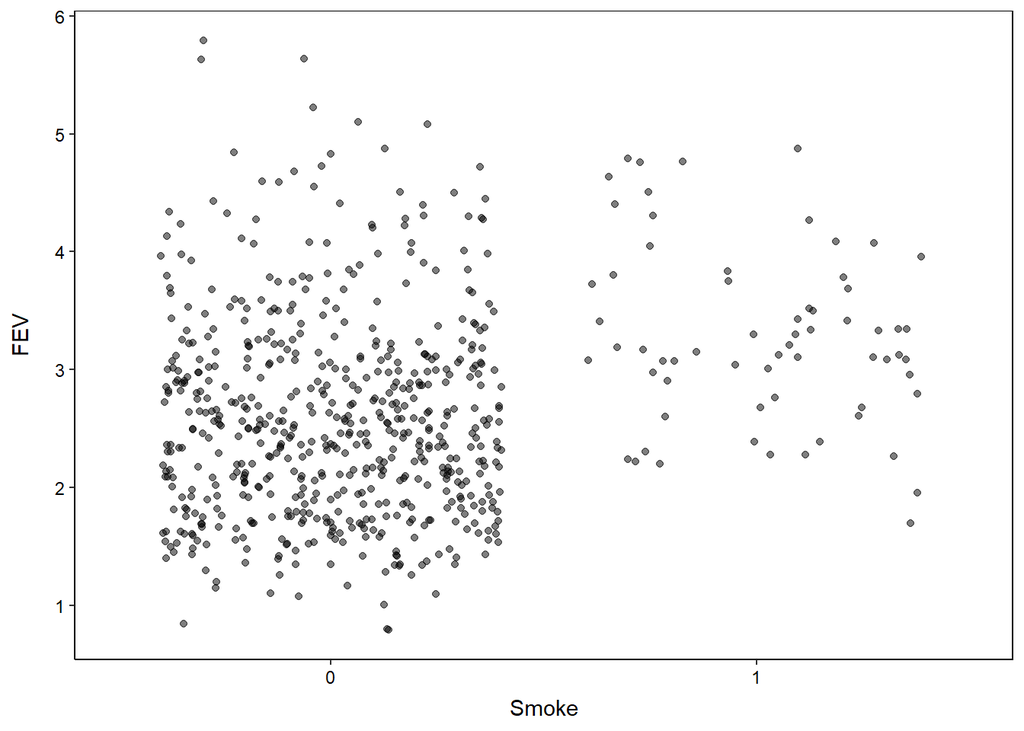

```r
# Another presentation
ggplot2::ggplot(data = lungcap, aes(x = Smoke, y = FEV)) +
  geom_jitter(alpha = 0.5)
```

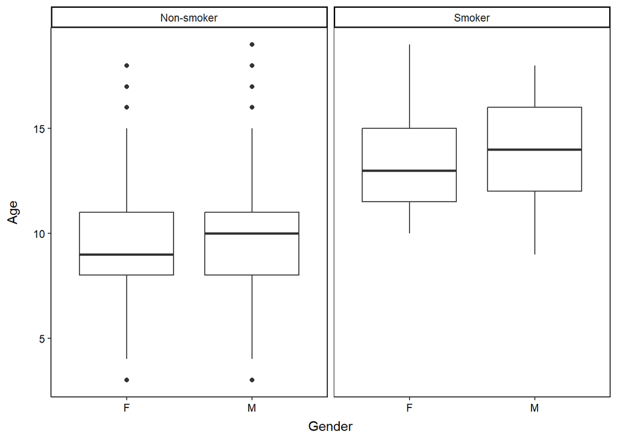

```r
# look at age
ggplot2::ggplot(data = lungcap, aes(x = Gender, y = Age)) +
  geom_boxplot() +
  facet_wrap(~Smoke,
             labeller = labeller(Smoke = c("0" = "Non-smoker", "1" = "Smoker"))) +
  scale_x_discrete(labels = c("0" = "Female", "1" = "Male"))
```

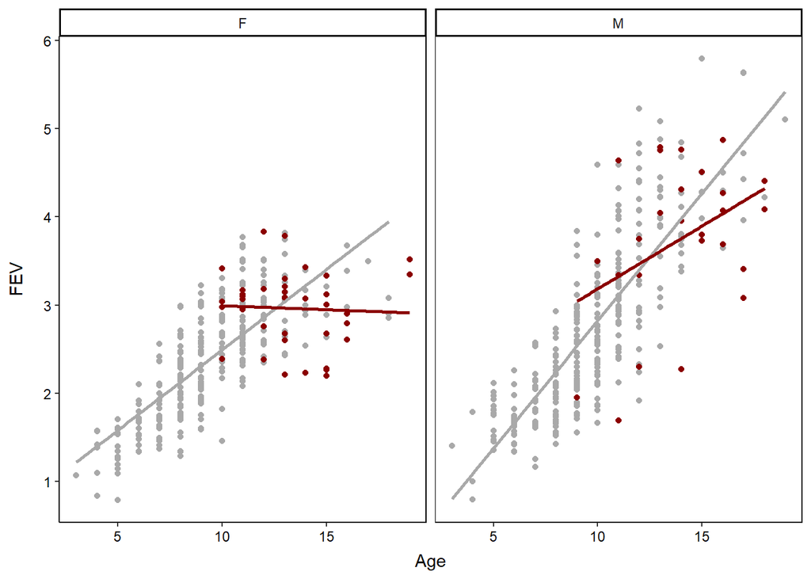

```r
# Plot FEV, taking age into account: LM lines
ggplot2::ggplot(data = lungcap, aes(x = Age, y = FEV, colour = factor(Smoke))) +
  geom_point() +
  scale_colour_manual(values = c("darkgrey", "darkred")) +
  geom_smooth(data = subset(lungcap, Smoke == 0), aes(group = 1),
              method = "lm", linewidth = 1, col = "darkgrey", se = FALSE) +
  geom_smooth(data = subset(lungcap, Smoke == 1), aes(group = 1),
              method = "lm", linewidth = 1, col = "darkred", se = FALSE) +
  facet_wrap(~Gender)
```

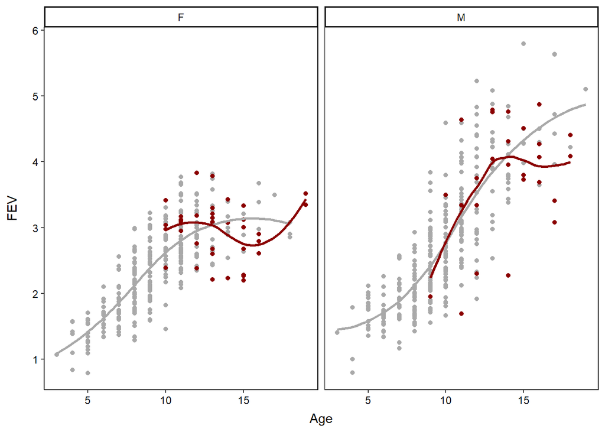

```r
# Plot FEV, taking age into account: loess lines
ggplot2::ggplot(data = lungcap, aes(x = Age, y = FEV, colour = factor(Smoke))) +
  geom_point() +
  scale_colour_manual(values = c("darkgrey", "darkred")) +
  geom_smooth(data = subset(lungcap, Smoke == 0), aes(group = 1),
              method = "loess", linewidth = 1, col = "darkgrey", se = FALSE) +
  geom_smooth(data = subset(lungcap, Smoke == 1), aes(group = 1),
              method = "loess", linewidth = 1, col = "darkred", se = FALSE) +
  facet_wrap(~Gender)
```

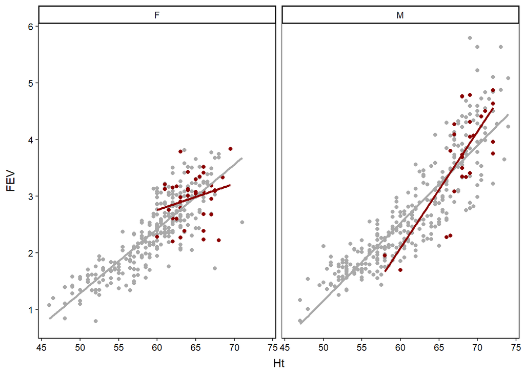

```r
# Plot FEV taking height into account: LM lines
ggplot2::ggplot(data = lungcap, aes(x = Ht, y = FEV, colour = factor(Smoke))) +
  geom_point() +
  scale_colour_manual(values = c("darkgrey", "darkred")) +
  geom_smooth(data = subset(lungcap, Smoke == 0), aes(group = 1),
              method = "lm", linewidth = 1, col = "darkgrey", se = FALSE) +
  geom_smooth(data = subset(lungcap, Smoke == 1), aes(group = 1),
              method = "lm", linewidth = 1, col = "darkred", se = FALSE) +
  facet_wrap(~Gender)
```

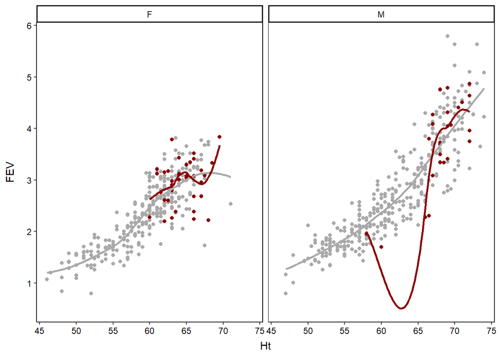

```r
# Plot FEV taking height into account: loess lines
ggplot2::ggplot(data = lungcap, aes(x = Ht, y = FEV, colour = factor(Smoke))) +
  geom_point() +
  scale_colour_manual(values = c("darkgrey", "darkred")) +
  geom_smooth(data = subset(lungcap, Smoke == 0), aes(group = 1),
              method = "loess", linewidth = 1, col = "darkgrey", se = FALSE) +
  geom_smooth(data = subset(lungcap, Smoke == 1), aes(group = 1),
              method = "loess", linewidth = 1, col = "darkred", se = FALSE) +
  facet_wrap(~Gender)
```

Let’s fit a few models:

```r
lung.glm.gaus.1 = glm(FEV ~ Smoke, data = lungcap, family = gaussian)
lung.glm.gaus.2 = glm(FEV ~ Smoke + Gender, data = lungcap, family = gaussian)
lung.glm.gaus.3 = glm(FEV ~ Smoke + Gender + Smoke:Gender,
                      data = lungcap, family = gaussian)

# model 2 is better than 1 -> including gender is NB
anova(lung.glm.gaus.1, lung.glm.gaus.2, test = "Chisq")
```

```
## Analysis of Deviance Table
##
## Model 1: FEV ~ Smoke
## Model 2: FEV ~ Smoke + Gender
##   Resid. Df Resid. Dev Df Deviance  Pr(>Chi)
## 1       652     461.35
## 2       651     435.91  1   25.436 7.125e-10 ***
## ---
## Signif. codes:  0 '***' 0.001 '**' 0.01 '*' 0.05 '.' 0.1 ' ' 1
```

```r
# model 3 is not particularly better than model 2 -> the interaction term
# is not that important
anova(lung.glm.gaus.2, lung.glm.gaus.3, test = "Chisq")
```

```
## Analysis of Deviance Table
##
## Model 1: FEV ~ Smoke + Gender
## Model 2: FEV ~ Smoke + Gender + Smoke:Gender
##   Resid. Df Resid. Dev Df Deviance Pr(>Chi)
## 1       651     435.91
## 2       650     433.40  1   2.5127  0.05223 .
## ---
## Signif. codes:  0 '***' 0.001 '**' 0.01 '*' 0.05 '.' 0.1 ' ' 1
```

```r
lung.glm.gaus.4 = glm(FEV ~ Smoke + Gender + Age,
                      data = lungcap, family = gaussian)

# model 4 is better than model 2 -> age is also important
anova(lung.glm.gaus.2, lung.glm.gaus.4, test = "Chisq")
```

```
## Analysis of Deviance Table
##
## Model 1: FEV ~ Smoke + Gender
## Model 2: FEV ~ Smoke + Gender + Age
##   Resid. Df Resid. Dev Df Deviance  Pr(>Chi)
## 1       651     435.91
## 2       650     191.78  1   244.13 < 2.2e-16 ***
## ---
## Signif. codes:  0 '***' 0.001 '**' 0.01 '*' 0.05 '.' 0.1 ' ' 1
```

```r
# add the interaction term between smoking and age
lung.glm.gaus.5 = glm(FEV ~ Smoke + Gender + Age + Smoke:Age,
                      data = lungcap, family = gaussian)

# model 5 is better than model 4 -> interaction between smoking and age is NB
anova(lung.glm.gaus.4, lung.glm.gaus.5, test = "Chisq")
```

```
## Analysis of Deviance Table
##
## Model 1: FEV ~ Smoke + Gender + Age
## Model 2: FEV ~ Smoke + Gender + Age + Smoke:Age
##   Resid. Df Resid. Dev Df Deviance  Pr(>Chi)
## 1       650     191.78
## 2       649     182.54  1   9.2409 9.933e-09 ***
## ---
## Signif. codes:  0 '***' 0.001 '**' 0.01 '*' 0.05 '.' 0.1 ' ' 1
```

```r
# add an interaction term between smoking, gender, and age
lung.glm.gaus.6 = glm(FEV ~ Smoke + Gender + Age + Smoke*Gender*Age,
                      data = lungcap, family = gaussian)

# model 6 is better than model 5
# adding the interaction between all three variables makes for a better model
anova(lung.glm.gaus.5, lung.glm.gaus.6, test = "Chisq")
```

```
## Analysis of Deviance Table
##
## Model 1: FEV ~ Smoke + Gender + Age + Smoke:Age
## Model 2: FEV ~ Smoke + Gender + Age + Smoke * Gender * Age
##   Resid. Df Resid. Dev Df Deviance  Pr(>Chi)
## 1       649     182.54
## 2       646     165.37  3   17.176 1.786e-14 ***
## ---
## Signif. codes:  0 '***' 0.001 '**' 0.01 '*' 0.05 '.' 0.1 ' ' 1
```

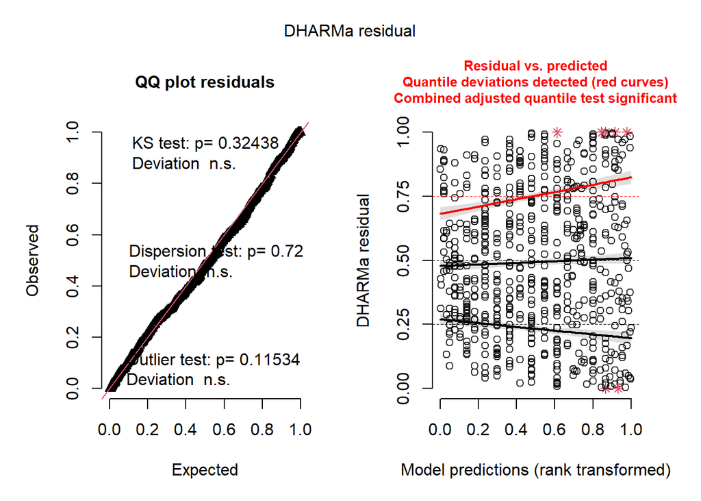

```
## Object of Class DHARMa with simulated residuals based on 250 simulations with refit = FALSE . See ?DHARMa::simulateResiduals for help.
##
## Scaled residual values: 0.404 0.132 0.288 0.46 0.608 0.504 0.616 0.22 0.38 0.312 0.272 0.212 0.18 0.46 0.644 0.492 0.56 0.48 0.088 0.248 ...
```

```r
# check model diagnostics
DHARMa::simulateResiduals(lung.glm.gaus.6, plot = TRUE)
```

```r
car::Anova(lung.glm.gaus.6, test = "LR", type = "III")
```

```
## Analysis of Deviance Table (Type III tests)
##
## Response: FEV
##                  LR Chisq Df Pr(>Chisq)
## Smoke              22.907  1  1.700e-06 ***
## Gender             23.311  1  1.378e-06 ***
## Age               261.203  1  < 2.2e-16 ***
## Smoke:Gender        0.577  1     0.4474
## Smoke:Age          24.917  1  5.987e-07 ***
## Gender:Age         48.074  1  4.104e-12 ***
## Smoke:Gender:Age    0.621  1     0.4308
## ---
## Signif. codes:  0 '***' 0.001 '**' 0.01 '*' 0.05 '.' 0.1 ' ' 1
```

```r
summary(lung.glm.gaus.6)
```

```
##
## Call:
## glm(formula = FEV ~ Smoke + Gender + Age + Smoke * Gender * Age,
##     family = gaussian, data = lungcap)
##
## Coefficients:
##                    Estimate Std. Error t value Pr(>|t|)
## (Intercept)         0.67387    0.10978   6.138 1.45e-09 ***
## Smoke1              2.41025    0.50359   4.786 2.11e-06 ***
## GenderM            -0.73143    0.15149  -4.828 1.72e-06 ***
## Age                 0.18209    0.01127  16.162  < 2e-16 ***
## Smoke1:GenderM     -0.58904    0.77534  -0.760    0.448
## Smoke1:Age         -0.19100    0.03826  -4.992 7.71e-07 ***
## GenderM:Age         0.10613    0.01531   6.934 9.97e-12 ***
## Smoke1:GenderM:Age  0.04497    0.05707   0.788    0.431
## ---
## Signif. codes:  0 '***' 0.001 '**' 0.01 '*' 0.05 '.' 0.1 ' ' 1
##
## (Dispersion parameter for gaussian family taken to be 0.2559873)
##
##     Null deviance: 490.92  on 653  degrees of freedom
## Residual deviance: 165.37  on 646  degrees of freedom
## AIC: 974.76
##
## Number of Fisher Scoring iterations: 2
```

```r
Rmisc::summarySE(data = lungcap, measurevar = "FEV",
                 groupvars = c("Gender", "Smoke"))
```

```
##   Gender Smoke   N      FEV        sd         se         ci
## 1      F     0 279 2.379211 0.6392629 0.03827167 0.07533908
## 2      F     1  39 2.965949 0.4228611 0.06771197 0.13707572
## 3      M     0 310 2.734381 0.9741337 0.05532708 0.10886548
## 4      M     1  26 3.743231 0.8894681 0.17443904 0.35926393
```

The summary output suggests that:

- The intercept (FEV) is 0.67 when all predictors are zero (age = 0, non-smoker, and female)
- Smoking (smoker = 1, non-smoker = 0) increases FEV by 2.41 units, compared to a non-smoker (holding all other variables constant)… weird! But, we haven’t accounted for age, gender, or height yet, which comes in with the interaction terms
- Gender affects FEV, where FEV is 0.73 units less in males than in females (holding all other variables constant)
- Age affects FEV, where a one year increase in age increases FEV by 0.18 units (holding all other variables constant)

**Interactions**:

- The effect of smoking on FEV differs between males and females, where FEV is 0.59 units less in male compared to female smokers. This isn’t significant, however.
- The effect of smoking on FEV differs across ages, where FEV decreases by 0.19 units with every year increase in age [in smokers], compared to non-smokers
- The effect of gender on FEV differs across ages, where FEV increases by 0.11 units more in males than females with every year increase in age
- There is a three-way interaction, suggesting that the effect of smoking on FEV differs between genders, and varies between ages, but this is not significant

Note the sample sizes in this data -> how might this affect our interpretation? The data points for non-smokers is much higher.

We also don’t know what the baseline lung capacity was for participants - there might have been some people with a genetic predisposition for a larger capacity, or maybe some people were physically a lot larger than others. These variables have not been accounted for. Aside from smoking or not, we don’t know what the unit of measurement was: some people might smoke two packets a day, while others smoke only one or two cigarettes per day. There might also be differences in other underlying health issues that could skew the results; perhaps some people have asthma or other lung-related illnesses, which also is not accounted for.